# Practical Machine Learning

Hayes Chow

2023-05-05

## Overview / Executive Summary

This project explores machine learning. Background info can be located here. https://www.coursera.org/learn/practical-machine-learning/supplement/PvInj/course-project-instructions-read-first

### Data

The training data for this project are available here:

https://d396qusza40orc.cloudfront.net/predmachlearn/pml-training.csv

The test data are available here:

https://d396qusza40orc.cloudfront.net/predmachlearn/pml-testing.csv

### Load data

Load data and remove any blank or columns with NA values.

```r
setwd("C:/Users/hchow/Downloads/Practical Machine Learning/course project")
data_train <- read.csv("pml-training.csv", na.strings = c("", "NA"))
data_test <- read.csv("pml-testing.csv", na.strings = c("", "NA"))
```

### Clean data

Clean the data by removing columns where over 90% of values are blank.

```r
x <- (colMeans(is.na(data_train))) * 100
blanks <- names(which(x > 90))
data_train <- data_train[ , !(names(data_train) %in% blanks)]
```

### Primary Component Analysis

Use primary component analysis to reduce number of variables. Determine that 25 varibles are required to cover 95% of variance.

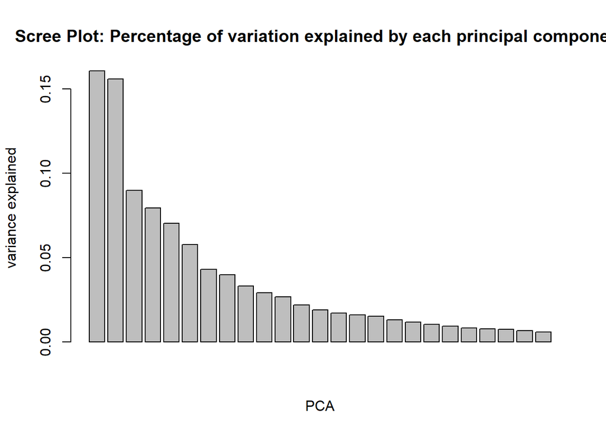

```r
pca_df <- prcomp(data_train[,8:59], scale = TRUE)
var_explained <- pca_df$sdev ^ 2 / sum(pca_df$sdev ^ 2)

# scree plot
barplot(var_explained[1:25], main="Scree Plot: Percentage of variation explained by each principal component", xlab="PCA", ylab = "variance explained")
```

```r
sum(var_explained[1:25]) # 25 Variables to get over 95% variance explained
```

```
## [1] 0.9545402
```

```r
pca_df_cols <- rownames(pca_df$rotation)[1:25] #list of columns

# keep only pca columns and rebind to predictor column
df2 <- cbind(data_train[, names(data_train) %in% pca_df_cols], factor(data_train[,60]))
# rename back the predictor column
colnames(df2) <- c(pca_df_cols, "classe")
```

### Machine Learning Algorithm - Random Forest

Why use random forest algorithm? Predictor variable contains 5 levels (“A”, “B”, “C”, “D”, “E”), representing 5 different ways barbell lifts are performed, so they are non-linear. Can’t use linear regression, or general linear model because it supports up to 2 classes or levels. Multi-class variable is well suited for random forests. Data is noisy (participants were asked to perform lifts both correctly and incorrectly) and variable, making it well-suited for random forest.

Use the random forest on the training dataset. Then use the trained model to predict values with test dataset. Set seed for reproducibility.

```r
set.seed(32343)
rf <- randomForest(classe ~ ., data = df2)
rf
```

```
##
## Call:
##  randomForest(formula = classe ~ ., data = df2)
##                Type of random forest: classification
##                      Number of trees: 500
## No. of variables tried at each split: 5
##
##         OOB estimate of  error rate: 1.03%
## Confusion matrix:
##      A    B    C    D    E class.error
## A 5546   15    8   11    0 0.006093190
## B   20 3761   14    1    1 0.009481169
## C    6   54 3344   17    1 0.022793688
## D    4    1   36 3172    3 0.013681592
## E    2    5    1    3 3596 0.003049626
```

Type of random forest is classification. 500 trees.

### Cross Validation

The Random forest algorithm includes cross-validation, so it is not necessary to use cross validation separately.

### Out of Sample Error

The Out of Sample (Out-of-box) estimate of error rate is 1.03%

### Predicted values

```r
p1 <- predict(rf, data_test)
p1
```

```
##  1  2  3  4  5  6  7  8  9 10 11 12 13 14 15 16 17 18 19 20
##  B  A  B  A  A  E  D  B  A  A  B  C  B  A  E  E  A  B  B  B
## Levels: A B C D E
```

## Conclusion

Confusion matrix compares predicted values with actual values for “Classe” variable.

```r
confusionMatrix(p1, quiz_classe)
```

```
## Confusion Matrix and Statistics
##
##           Reference
## Prediction A B C D E
##          A 7 0 0 0 0
##          B 0 8 0 0 0
##          C 0 0 1 0 0
##          D 0 0 0 1 0
##          E 0 0 0 0 3
##
## Overall Statistics
##
##                Accuracy : 1
##                  95% CI : (0.8316, 1)
##     No Information Rate : 0.4
##     P-Value [Acc > NIR] : 1.1e-08
##
##                   Kappa : 1
##
##  Mcnemar's Test P-Value : NA
##
## Statistics by Class:
##
##                      Class: A Class: B Class: C Class: D Class: E
## Sensitivity              1.00      1.0     1.00     1.00     1.00
## Specificity              1.00      1.0     1.00     1.00     1.00
## Pos Pred Value           1.00      1.0     1.00     1.00     1.00
## Neg Pred Value           1.00      1.0     1.00     1.00     1.00
## Prevalence               0.35      0.4     0.05     0.05     0.15
## Detection Rate           0.35      0.4     0.05     0.05     0.15
## Detection Prevalence     0.35      0.4     0.05     0.05     0.15
## Balanced Accuracy        1.00      1.0     1.00     1.00     1.00
```

## References

https://medium.com/@aravanshad/gradient-boosting-versus-random-forest-cfa3fa8f0d80 https://www.guru99.com/r-random-forest-tutorial.html https://www.listendata.com/2014/11/random-forest-with-r.html https://www.projectpro.io/recipes/perform-random-forest-r#mcetoc_1g5vh1b90e https://www.statology.org/scree-plot-r/ https://www.digitalocean.com/community/tutorials/confusion-matrix-in-r